# Differential protein abundance analysis (Joan Chang, Liz Laird)

Fraction 1 - data processing and statistical inference

# Introduction

This report details the analysis pipeline for this proteomic study, which includes data processing steps to filter and normalize the peptide data, unsupervised exploratory analyses such as Principal Component Analysis (PCA) and hierarchical clustering, and statistical analyses to identify differentially expressed proteins.

For the comparative analysis, we used the **msqrob2** package, which implements a robust linear (mixed) model framework for differential abundance testing. Briefly, a model is fitted per protein, with the experimental design specified as a formula; fixed and random effects can be included, so that nested designs, batch structure and technical replication are modelled explicitly rather than collapsed into a two-sample test. Parameter estimates are stabilised by three mechanisms: robust M-estimation, which down-weights outliers rather than discarding them; ridge regression, which shrinks coefficients and stabilises estimation when a protein is quantified by few or unbalanced peptides; and empirical Bayes moderation of the residual variance, which borrows information across proteins to improve variance estimates in small-sample designs. Contrasts of interest are then tested using moderated t-statistics, and p-values are corrected for multiple testing across proteins with using Benjamini–Hochberg correction.

```r
packages = c("tidyverse",
             "plotly",
             "QFeatures",
             "msqrob2",
             "MSnbase",
             "kableExtra",
             "mixOmics",
             "reshape2",
             "openxlsx",
             "patchwork",
             "ggrepel",
             "Hmisc",
             "pheatmap",
             "DT",
             "clusterProfiler",
             "enrichplot",
             "org.Mm.eg.db")

for(i in packages){
  if(!require(i, character.only = TRUE)){
    install.packages(i)
  }
  library(i, character.only = TRUE)
}

# custom functions
## z-score for plotting
zscore_custom = function(x) {
  (x - mean(x, na.rm = T))/sd(x, na.rm = T)
  }
```

# Input data

The MS/MS data was searched against the mouse proteome, obtained from UniProtKB (Proteome UP000000589, downloaded on 03/08/2026; containing 54,857 protein sequences) using FragPipe’s integrated search algorithm MSFragger. The search generates a **combined_peptide.tsv**, which contains 1% FDR-filtered peptides from all experimental groups, where each row is a (stripped) peptide sequence, and their respective normalized intensities.

Briefly, the search was performed with the following settings:

- Precursor mass tolerance: 20 ppm (window is +/- this value)
- Fragment mass tolerance: 20 ppm
- Protease: Trypsin, with 2 missed cleavages allowed per peptide
- Fixed modifications: carbamidomethylation of cysteine (+57.02146 Da)
- Variable modifications: oxidation of methionine (+15.9949 Da), N-terminal acetylation (+42.0106 Da)
- Peptide length: 7 to 50 residues
- Precursor mass tolerance: 500 to 5000 Da

A target-decoy search strategy was applied to control for false-positive identifications, maintaining a 1% FDR for both peptide-spectrum matches and protein groups. The match-between-runs algorithm was enabled during the analysis to increase the number of identifications. Contaminants were identified based on matches to the contaminants database.

```r
# Load the peptide data
peptides = "combined_peptide.tsv" # use the combined peptide as input data

peptide_data = data.table::fread(peptides, check.names = TRUE,
                                 integer64 = "double", sep = "\t")

# Remove the peptides that map to decoy sequences or to contaminants proteins
peptide_data = peptide_data[!grepl("contam_|rev_", peptide_data$Protein), ]

# Locate expression variables in the peptide table
quantCols = grep("\\d+.Intensity", names(peptide_data), value = TRUE)

# Identify pooled samples (if present) and remove it
if(any(grepl("pool", names(peptides[quantCols]), ignore.case = TRUE))) {
  quantCols <- quantCols[!grepl("pool", names(peptides[quantCols]), ignore.case = TRUE)]
  }
```

## Metadata table detailing study design

- Group A: C57BL6/J; Wt for oim
- Group B: oim/oim homozgyote on C57BL6/J
- Group C: C57BL6N; Wt for Col1a2 null
- Group D: Col1a2 null (-/-) (tm1b) on C57BL6N

Comparisons will be performed as:

- Group B vs. Group A
- Group C vs. Group A
- Group D vs. Group C
- Group D vs. Group B

```r
annot = data.frame(quantCols = quantCols)
annot = annot |>
  dplyr::mutate(
    SampleId = gsub(".Intensity", "", quantCols),
    condition = gsub("_\\d+.Intensity", "", quantCols),
    Replicate = rep(1:3, 4)
  )

annot |>
  kbl(caption = "Experimental annotation") |>
  kable_material() |>
  kable_styling(fixed_thead = TRUE, full_width = TRUE,
                bootstrap_options = c("striped", "hover"),
                font_size = 16) |>
  scroll_box(width = "100%", height = "300px") |>
  row_spec(0, color = "black", bold = TRUE)
```

Table 1: Experimental design

Experimental annotation

| quantCols | SampleId | condition | Replicate |
| --- | --- | --- | --- |
| Group_A_1.Intensity | Group_A_1 | Group_A | 1 |
| Group_A_2.Intensity | Group_A_2 | Group_A | 2 |
| Group_A_3.Intensity | Group_A_3 | Group_A | 3 |
| Group_B_1.Intensity | Group_B_1 | Group_B | 1 |
| Group_B_2.Intensity | Group_B_2 | Group_B | 2 |
| Group_B_3.Intensity | Group_B_3 | Group_B | 3 |
| Group_C_1.Intensity | Group_C_1 | Group_C | 1 |
| Group_C_2.Intensity | Group_C_2 | Group_C | 2 |
| Group_C_3.Intensity | Group_C_3 | Group_C | 3 |
| Group_D_1.Intensity | Group_D_1 | Group_D | 1 |
| Group_D_2.Intensity | Group_D_2 | Group_D | 2 |
| Group_D_3.Intensity | Group_D_3 | Group_D | 3 |

## Convert to QFeatures object

For this pipeline, we use the peptide data table to generate a QFeatures object so we can directly use QFeatures’ data preprocessing functionality. QFeatures allows to build highly modular workflows, where each step is carried out by a dedicated function with a large choice of available methods and parameters, which lets the users to adapt the workflow to their specific use case and their specific needs.

We use the `readQFeatures()` from the **QFeatures** package, which converts a tabular data into a QFeatures object. We provide the peptide table and the sample annotation table. The function will use the quantCols column in the sample annotation table to understand which columns in peptides contain the quantitative values, and automatically link the corresponding sample annotation with the quantitative values. We also tell the function to use the Sequence column as peptide identifier, which will be used as row names.

Following, we apply a function to correctly encode the missing values because it is important that missing values are encoded using *NA*. For instance, non-observed values should not be encoded with a zero because true zeros (the proteomic feature is absent from the sample) cannot be distinguished from technical zeros (the feature was missed by the instrument or could not be identified). We therefore replace any zero in the quantitative data with *NA*.

Next, we log2-transform the peptide intensities to mitigate the impact of highly variable peptide intensities and enhances the comparability of the data. This step is essential for downstream statistical analyses, which often assume normally distributed data. Furthermore, with this transformation, we can visually inspect the data distribution to identify discrete variations in peptide signal distribution among replicates, with some noise, and whether there is a necessity for normalization.

```r
# Create an S4 object, QFeatures type
pep =
  QFeatures::readQFeatures(
    assayData = peptide_data,    # quantitative peptide data
    colData = annot,             # metadata
    quantCols = quantCols,       # expression indexes: using IonQuant Intensities here
    fnames = "Peptide.Sequence", # feature names
    name = "raw",                # assay name
    sep = "\t"
  )

# Convert zeroes to NA
pep = QFeatures::zeroIsNA(object = pep, i = "raw")

# log2-transformation
pep = QFeatures::logTransform(pep, base = 2, i = "raw", name = "log")
```

```r
# Brief summary
cat(paste("The dataset contains",
          nrow(assay(pep[["log"]])), "peptide sequences and",
          ncol(assay(pep[["log"]])), "samples")
    )
```

```
The dataset contains 30150 peptide sequences and 12 samples
```

# QC: missing values

Missing MS signal values is a common feature in discovery proteomics, and can influence the robustness of further analyses. Mass spectrometry does not measure every protein in every sample. Because the instrument selects peptides for fragmentation semi-randomly, and because low-abundance peptides fall below the detection limit in some runs but not others, the final data table contains a substantial number of empty cells. These gaps carry information that provide insights into patterns and biases within the dataset, and ultimately constrains which proteins can be tested statistically.

Examining the distribution and prevalence of missing MS values helps identify patterns and potential biases in the dataset, which should be handled properly during data wrangling so the results of the later analyses are robust and reliable. Overall, missing values should be randomly distributed across the replicates, and if not, that could indicate systematic issues that need to be addressed.

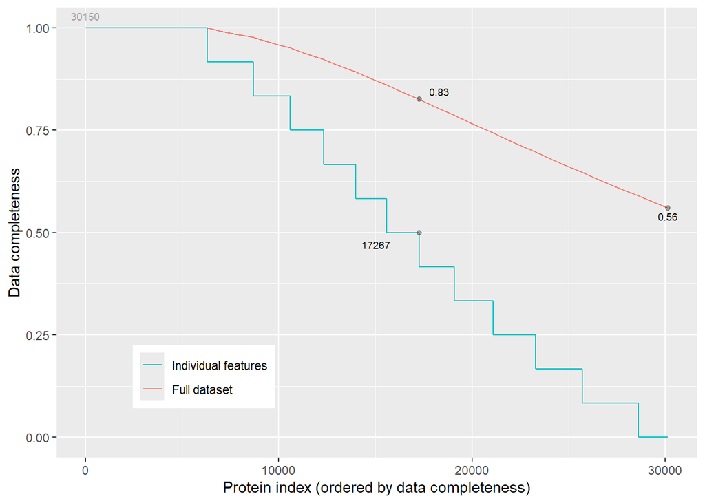

Figure 1: Distribution of missing values in the dataset

```r
MSnbase::plotNA(assay(pep[["log"]]))
```

# Preprocessing

Here, the peptide data is submitted to a series of filtering steps aimed to enhance the quality of the peptide data and appropriate normalization to remove systematic biases to prepare it for subsequent analyses.

## Peptide filtering

Filtering steps will remove peptides not-suitable for analysis. These include peptides that failed during protein inference, or matching to contaminant proteins and reverse sequences (decoys) or to multiple smaller protein groups, and peptides detected in only one sample. This rigorous filtering ensures that only high-confidence peptides are considered for the analysis.

```r
# failed protein inference (if any)
prot = rowData(pep[["log"]])$Protein
rowData(pep[["log"]])$has_protein = !is.na(prot) & trimws(prot) != ""
#sum(!rowData(pep[["log"]])$has_protein)          # report this; likely 0
pep = QFeatures::filterFeatures(pep, ~ has_protein, keep = TRUE)

# gene-level uniquenes
mg = rowData(pep[["log"]])$Mapped.Genes
rowData(pep[["log"]])$gene_unique = is.na(mg) | trimws(mg) == ""
#table(rowData(pep[["log"]])$gene_unique)
pep = QFeatures::filterFeatures(pep, ~ gene_unique, keep = TRUE)

# remove peptides with high missingness rates: add column with count of non-zero values to assay array
# keep peptides that were detected in at least two samples, for modelling of peptide characteristics later with msqrob2
rowData(pep[["log"]])$nNonZero = rowSums(!is.na(assay(pep[["log"]])))
pep = QFeatures::filterFeatures(pep, ~ nNonZero > 1, keep = TRUE)

cat(paste("Before filtering, the dataset comprised a total of",
      nrow(assay(pep[["raw"]])), "peptide sequences. After filtering was performed, it now comprises",
      nrow(assay(pep[["log"]])), "peptide sequences."))
```

```
Before filtering, the dataset comprised a total of 30150 peptide sequences. After filtering was performed, it now comprises 23332 peptide sequences.
```

After filtering was applied, we can inspect various peptide measurements. Figure 2 illustrates the total peptide signal detected and missed in each replicate sample within the respective samples. These measurements facilitate the assessment of variability between replicates and the overall quality of the data

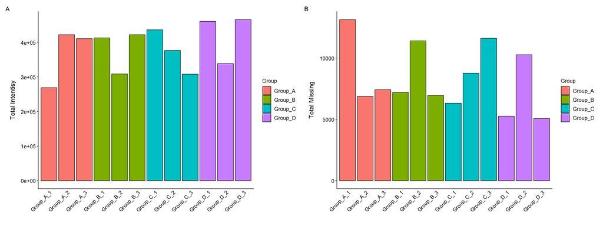

Figure 2: Peptide data filtered - (A) Summed raw intensity from all peptides in each sample. (B) Total of peptides not quantified in each sample

```r
raw_pep = as_tibble(assay(pep[["log"]]))

raw_summarized = tibble(
  "samples" = annot$SampleId,
  "total_intensity" = apply(raw_pep, 2, function(x) sum(x, na.rm = TRUE)),
  "missing_values" = apply(raw_pep, 2, function(x) sum(is.na(x))),
)


QCfilt1 =
  ggplot(raw_summarized,
         aes(x = samples,
             y = total_intensity,
             fill = annot$condition)) +
  geom_bar(color = "black", stat = "identity") +
  labs(tag = "A", fill = "Group") +
  xlab("") +
  ylab("Total Intentisy") +
  theme_classic() +
  theme(axis.text.x = element_text(size = 10, color = "black",
                                   angle = 45, hjust = 1, vjust = 1),
        axis.text.y = element_text(size = 10, color = "black"),
        axis.ticks.x = element_blank(),
        axis.title.x = element_text(size = 12, color = "black"),
        axis.title.y = element_text(size = 12, color = "black",
                                    margin = margin(0,10,0,0)),
        legend.text = element_text(size = 10),
        legend.title = element_text(size = 10),
        plot.tag = element_text(size = 12)
        )

QCfilt2 =
  ggplot(raw_summarized,
         aes(x = samples,
             y = missing_values,
             fill = annot$condition)) +
  geom_bar(color = "black", stat = "identity") +
  labs(tag = "B", fill = "Group") +
  xlab("") +
  ylab("Total Missing") +
  theme_classic() +
  theme(axis.text.x = element_text(size = 10, color = "black",
                                   angle = 45, hjust = 1, vjust = 1),
        axis.text.y = element_text(size = 10, color = "black"),
        axis.ticks.x = element_blank(),
        axis.title.x = element_text(size = 12, color = "black"),
        axis.title.y = element_text(size = 12, color = "black",
                                    margin = margin(0,10,0,0)),
        legend.text = element_text(size = 10),
        legend.title = element_text(size = 10),
        plot.tag = element_text(size = 12)
        )

QCfilt1+QCfilt2
```

In Figure 2 (A), note disparity in total intensity between samples within each group is as follows:

- Group A = 1.57-fold change
- Group B = 1.37-fold change
- Group C = 1.42-fold change
- Group D = 1.38-fold change

In Figure 2 (B), it becomes evident that samples with lower total intensity signals also present a higher number of unquantified peptides.

## Peptide normalization

The most common objective of MS-based proteomics experiments is to understand the biological changes in protein abundance between experimental conditions. However, changes in measurements between groups can be caused due to technical factors such as differences in sample preparation or instrument performance. Normalization corrects for these systematic biases and variability between samples, ensuring that differences observed in the data are due to biological variation rather than technical artefacts.

Figure 3 shows the distribution of the log2-transformed peptide intensities across each replicate prior to normalization. We use this to diagnose the need for normalization to account for technical variability between replicates.

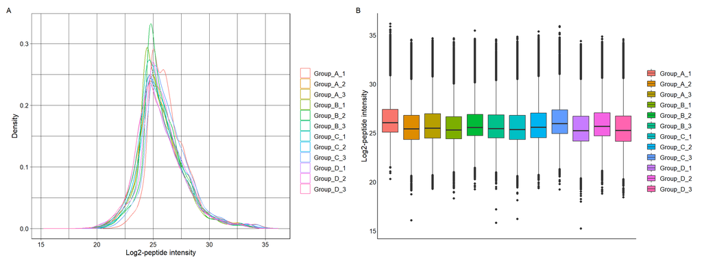

Figure 3: Distribution of peptide data - (A) Histogram and (B) box plot displaying the **non-normalized** log2-transformed peptide intensities in each sample.

```r
hist1 =
  ggplot(reshape2::melt(assay(pep[["log"]]))) +
  geom_density(aes(x = value,
                   color = gsub(".Intensity", "", Var2))) +
  xlab("Log2-peptide intensity") + ylab("Density") +
  labs(color = "", tag = "A") +
  theme_linedraw() +
  theme(axis.text = element_text(size = 10, color = "black"),
        axis.title = element_text(size = 12, color = "black"),
        legend.text = element_text(size = 10),
        plot.tag = element_text(size = 12)
        )

bp1 =
  ggplot(reshape2::melt(assay(pep[["log"]]))) +
  geom_boxplot(aes(x = Var2, y = value,
                   fill = gsub(".Intensity", "", Var2))) +
  ylab("Log2-peptide intensity") + xlab("") +
  labs(fill = "", tag = "B") +
  theme_classic() +
  theme(axis.text.x = element_blank(),
        axis.text.y = element_text(size = 10, color = "black"),
        axis.ticks = element_blank(),
        axis.title = element_text(size = 12, color = "black"),
        legend.text = element_text(size = 10),
        plot.tag = element_text(size = 12)
        )

hist1+bp1
```

Both the histogram (A) and box plot (B) reveal notable variations in peptide signal distribution among all replicates, both within and across groups. Note that the marginal precursor intensity distributions across samples are not well aligned. Ignoring this effect will increase the noise and reduce the statistical power of the experiment, and may also, in case of unbalanced designs, introduce confounding effects that will bias the results.

There are many ways to perform the normalisation, e.g. median centring is a popular choice. If we subtract the sample median at the log scale from each precursor log2 intensity, centring the data around zero - this basically boils down to calculating log-ratios between the precursor intensity and its sample median. For this, we use a matrix containing peptide intensity values to apply median centring, which will help to reduce technical variability and improve the comparability of samples. Figure 4 shows the distribution of the peptide intensities per sample, before and after normalization

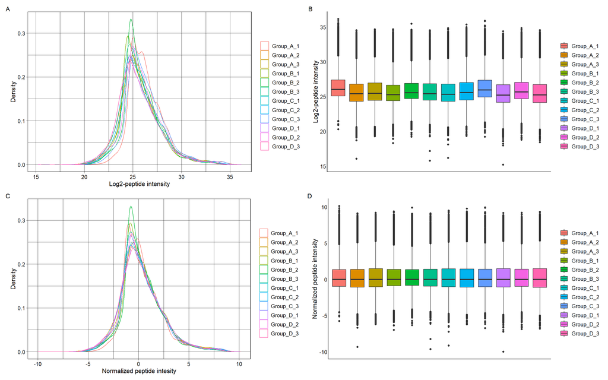

Figure 4: Distribution of peptide data - Histogram and box plot displaying the non-normalized (A-B) and normalized (C-D) peptide intensities in each sample.

```r
# Apply median centring
pep = QFeatures::normalize(pep, i = "log", method = "center.median", name = "norm")

hist2 =
  ggplot(reshape2::melt(assay(pep[["norm"]]))) +
  geom_density(aes(x = value,
                   color = gsub(".Intensity", "", Var2))) +
  xlab("Normalized peptide intesity") + ylab("Density") +
  labs(color = "", tag = "C") +
  theme_linedraw() +
  theme(axis.text = element_text(size = 10, color = "black"),
        axis.title = element_text(size = 12, color = "black"),
        legend.text = element_text(size = 10),
        plot.tag = element_text(size = 12)
        )

bp2 =
  ggplot(reshape2::melt(assay(pep[["norm"]]))) +
  geom_boxplot(aes(x = Var2, y = value,
                   fill = gsub(".Intensity", "", Var2))) +
  ylab("Normalized peptide intensity") + xlab("") +
  labs(fill = "", tag = "D") +
  theme_classic() +
  theme(axis.text.x = element_blank(),
        axis.text.y = element_text(size = 10, color = "black"),
        axis.ticks = element_blank(),
        axis.title = element_text(size = 12, color = "black"),
        legend.text = element_text(size = 10),
        plot.tag = element_text(size = 12)
        )

(hist1+bp1)/(hist2+bp2)
```

# Summarization to protein level

Aggregation from the peptide to protein level is achieved using robust aggregation for each protein. Table 2 presents all proteins identified in at least two samples from this dataset.

```r
# Summarization from peptide to protein level
pep =
  aggregateFeatures(
    object = pep,
    i = "norm",
    fcol = "Protein.ID",
    name = "prot",
    na.rm = TRUE
    )
```

```r
# Extract protein list:
protein_data = as.data.frame(assay(pep[["prot"]]))
protein_data$Protein = rowData(pep[["prot"]])$Protein.ID
protein_data$Gene = rowData(pep[["prot"]])$Gene
protein_data =
  protein_data |>
  dplyr::relocate(Protein, Gene) |>
  dplyr::arrange(Protein)

colnames(protein_data) = gsub(".Intensity", "", colnames(protein_data))
#write.xlsx(x = protein_data, file = "Protein_list.xlsx")

# Protein table
DT::datatable(protein_data,
              rownames = FALSE,
              extensions = 'Buttons',
              options = list(dom = 'Bfrtip', buttons = 'excel'))
```

| Protein | Gene | Group_A_1 | Group_A_2 | Group_A_3 | Group_B_1 | Group_B_2 | Group_B_3 | Group_C_1 | Group_C_2 | Group_C_3 | Group_D_1 | Group_D_2 | Group_D_3 |
| --- | --- | --- | --- | --- | --- | --- | --- | --- | --- | --- | --- | --- | --- |
| A0A075B5M7 | Igkv5-39 | -0.711711727031143 | -0.5954839190723886 | 1.995895783904144 |  |  |  | -2.364448891844062 | 1.188771746861538 | 1.253817812503559 | 1.283028102244511 | 0.0869321931164749 | 0.5800969469746543 |
| A0A075B5P3 | Ighg2b | -0.4861776733465524 | -1.615555307519695 | 0.6719524480657543 | -3.299194498166964 | -2.345763568913743 |  | -0.670260312931902 | -1.905223998532602 | -0.254669098223029 | -1.006848361829505 | -1.267506201651704 | -1.513895936565053 |
| A0A075B5P4 | Ighg1 | -0.1022458998650002 | 0.4500501091043301 | 0.6174538716975951 | -1.404664424612841 | -3.280284622967718 | -1.700857008232351 | 0.7221243118470024 | 0.7369076826139017 | 1.197059532495791 | 1.083146917554394 | -0.1618521081745907 | 0.3211032478213021 |
| A0A075B5P9 | Ighv5-4 |  | -2.680690082108644 | -1.345131737377109 |  |  |  | -0.06354429885261226 |  |  |  |  |  |
| A0A075B5R5 | Ighv4-1 |  |  | -1.471380539389354 |  |  |  | -0.6460588423708344 | -1.618475171736275 | -0.9734713216499564 | -1.411907894800652 |  |  |
| A0A075B5T2 | Ighv6-3 | -2.442511985560981 | -0.655960491302677 | -1.522245851424275 |  |  | 0.3329465030745984 | -2.393795274725558 |  |  | -1.708329411509421 |  |  |
| A0A075B6A3 | Igha | 0.3358139775942384 |  |  |  |  |  | -1.900240083128644 |  |  |  |  |  |
| A0A087WPF8 | Abhd14b | -1.025529309232978 | 0.37889802036436 | -0.373164606418634 | 0.002102646201636079 | -0.3675743872372551 | -0.5123556564642932 | -0.2448256923127692 | -0.4480011751434081 | -0.8638637585951621 | -0.6434275160316681 | -0.7285244410267842 | -0.6052344865021638 |
| A0A087WPJ7 | Dnajc13 |  | -2.836157442331638 | -3.62578153686834 | -2.197193988597109 | -1.939439990036962 | -1.859214676657536 |  | -3.407139982166049 |  | -1.427439218503348 | -1.907680925404318 | -1.626333491892396 |
| A0A087WPL5 | Dhx9 | -1.334846859242937 | -0.5363534279114798 | -0.7520465725713635 | -0.4787076506621706 | -0.3905592231483503 | -0.3609552762723942 | -0.3462723135507812 | -0.6383788442573042 | -1.095413742209924 | -0.4598138432125835 | -0.588698372876309 | -0.3705059669041968 |

[output cut: 3666 more lines]

## Data exploration and QC after summarization

Data exploration aims to highlight the main sources of variation in the data prior to data modelling and can pinpoint to outlying or off-behaving samples. Figure 5 shows the marginal distribution at precursor and protein level.

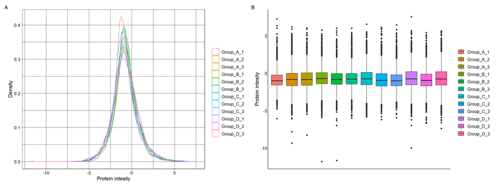

```r
hist3 =
  ggplot(reshape2::melt(assay(pep[["prot"]]))) +
  geom_density(aes(x = value,
                   color = gsub(".Intensity", "", Var2))) +
  xlab("Protein intesity") + ylab("Density") +
  labs(color = "", tag = "A") +
  theme_linedraw() +
  theme(axis.text = element_text(size = 10, color = "black"),
        axis.title = element_text(size = 12, color = "black"),
        legend.text = element_text(size = 10),
        plot.tag = element_text(size = 12)
        )

bp3 =
  ggplot(reshape2::melt(assay(pep[["prot"]]))) +
  geom_boxplot(aes(x = Var2, y = value,
                   fill = gsub(".Intensity", "", Var2))) +
  ylab("Protein intesity") + xlab("") +
  labs(fill = "", tag = "B") +
  theme_classic() +
  theme(axis.text.x = element_blank(),
        axis.text.y = element_text(size = 10, color = "black"),
        axis.ticks = element_blank(),
        axis.title = element_text(size = 12, color = "black"),
        legend.text = element_text(size = 10),
        plot.tag = element_text(size = 12)
        )

hist3+bp3
```

Figure 6 shows the total number of identifications per sample in the study.

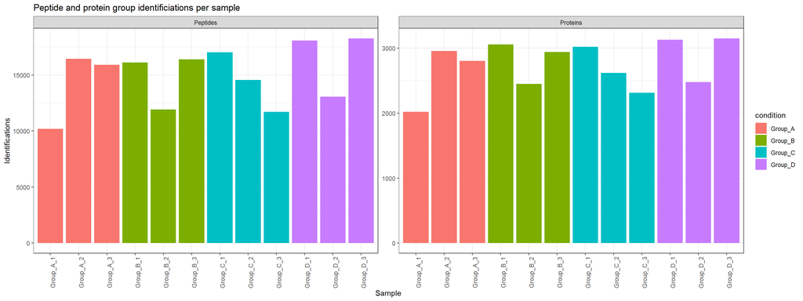

Figure 6: Number of peptides and proteins per sample.

```r
pep[,,"norm"] |>
  longForm(colvars = colnames(colData(pep)),
           rowvars= c("Peptide.Sequence",
                      "Protein.ID")) |>
  data.frame() |>
  filter(!is.na(value)) |>
  group_by(condition, SampleId) |>
  summarise(Peptides = length(unique(Peptide.Sequence)),
            Proteins = length(unique(Protein.ID))) |>
  pivot_longer(-(1:2),
               names_to = "Feature",
               values_to = "IDs") |>
  ggplot(aes(x = SampleId, y = IDs, fill = condition)) +
  geom_col() +
  #scale_fill_observable() +
  facet_wrap(~Feature,
             scales = "free_y") +
  labs(title = "Peptide and protein group identificiations per sample",
       x = "Sample",
       y = "Identifications") +
  theme_bw() +
  theme(axis.text.x = element_text(angle = 90))
```

## Principal Component Analysis

The next step involves investigating the sources of variation in the data and identifying potential outliers that will need to be addressed before conducting statistical analyses. Principal Component Analysis (PCA) identifies variation patterns in the data and simplifies the dataset by reducing the number of variables while retaining the majority of its essential information. The initial step involves calculating the overall rate of missing values in the dataset.

Missing values, if random, typically do not significantly affect PCA unless they are excessively prevalent. It is advisable to filter features with a high rate of missing values and impute the remaining missing values. Proteins with an excessive number of missing values should be excluded to maintain the accuracy of the principal components calculation. Typically, a 20-30% threshold is applied to the data to determine whether variables with an excessive number of missing values should be removed. If this assumption is not met, variables with excessive missing values should be removed to maintain the precision of the principal components’ calculation.

```r
prop.na = function(df){
  num.NA = sum(is.na(dplyr::select_if(df, is.numeric)))
  num.nNA = sum(!is.na(dplyr::select_if(df, is.numeric)))
  prop.na = 100*(num.NA/(num.nNA+num.NA))

  if(prop.na > 20){
    cat(paste("The proportion of missing values in the dataset exceeds 20%, the next step is to remove variables with an excessive number of missing values, specifically those that were not quantified in more than 20% of the samples."))

  } else{
    cat(paste("The proportion of missing values in the dataset at hand is less than 20%, hence, no filtering for variables with with an excessive number of missing values is required."))
  }
  }

prop.na(protein_data)
```

```
The proportion of missing values in the dataset exceeds 20%, the next step is to remove variables with an excessive number of missing values, specifically those that were not quantified in more than 20% of the samples.
```

```r
remove_variables = function(df){
  # calculate NA rate per variable (proteins displayed in rows)
    df$prop.na = apply(select_if(df, is.numeric), 1, function(x) sum(is.na(x))/length(x))

  # remove variables with > 20% values missing
    df = df |>
      dplyr::filter(prop.na < 0.2) |>
      dplyr::select(!c(Protein, Gene, prop.na))
    }

protein_filtered = remove_variables(protein_data)

cat(paste("A total of", nrow(protein_data)-nrow(protein_filtered),
          "proteins were removed from the original protein list, resulting in a filtered dataset containing",
          nrow(protein_filtered), "proteins selected for further analysis using Principal Component Analysis."))
```

```
A total of 1570 proteins were removed from the original protein list, resulting in a filtered dataset containing 2106 proteins selected for further analysis using Principal Component Analysis.
```

Missing values should be further imputed, and here, the [NIPALS](http://mixomics.org/methods/missing-values/) algorithm, from the **mixOmics** package is used to decompose the dataset and extract information used for reconstructing the original data. Estimated values replace the missing ones before proceeding with PCA.

```r
# transpose the data
protein_t =
  protein_filtered |>
  t()

# impute missing values with NIPALS
set.seed(123)
protein_t = mixOmics::impute.nipals(protein_t, ncomp = nrow(protein_t))

# Global adequacy for PCA
## Pearson correlation matrix
rcor = Hmisc::rcorr(protein_t)

## Bartlett's sphericity test
## if $p.value < 0.05, a PCA is adequate
#psych::cortest.bartlett(rcor$r, n = nrow(rcor$r)) # $p.value = 0
```

```r
pca = mixOmics::pca(X = protein_t, ncomp = 3, center = TRUE, scale = FALSE)
```

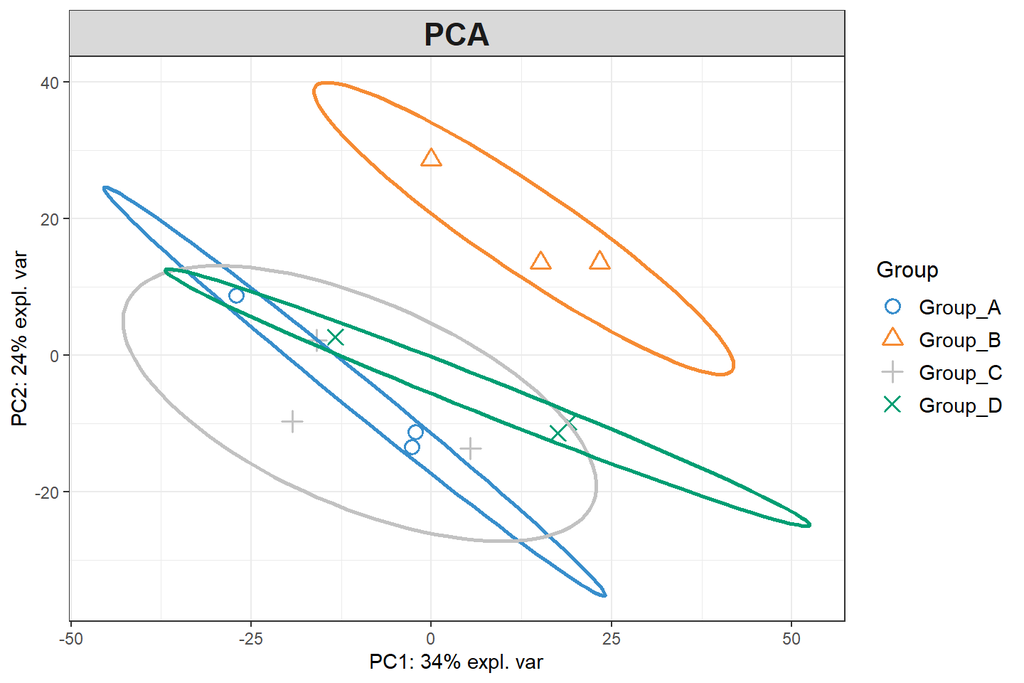

Figure 7: PCA: samples are color-coded by group and distributed across the space defined by PC1 and PC2.

```r
plotIndiv(object = pca,
          comp = c(1,2),
          ind.names = FALSE,
          ellipse = TRUE,
          group = annot$condition,
          legend = TRUE,
          legend.title = "Group",
          title = "PCA"
          )
```

```r
#ggsave("pca_plot.png",
#       plot =
#         plotIndiv(object = pca,
#                   comp = c(1,2),
#                   ind.names = FALSE,
#                   ellipse = TRUE,
#                   group = annot$condition,
#                   legend = TRUE,
#                   legend.title = "Group",
#                   title = "PCA"
#                   )$graph,
#       dpi = 600, width = 7.5, height = 5)
```

# Statistical analysis

```r
rowData(pep[["prot"]])$naA = apply(assay(pep[["prot"]])[, 1:3],   1, function(x) sum(is.na(x)))
rowData(pep[["prot"]])$naB = apply(assay(pep[["prot"]])[, 4:6],   1, function(x) sum(is.na(x)))
rowData(pep[["prot"]])$nac = apply(assay(pep[["prot"]])[, 7:9],   1, function(x) sum(is.na(x)))
rowData(pep[["prot"]])$nad = apply(assay(pep[["prot"]])[, 10:12], 1, function(x) sum(is.na(x)))

filter_prot = (rowData(pep[["prot"]])$naA < 2 & rowData(pep[["prot"]])$naB < 2 & rowData(pep[["prot"]])$naB < 2 & rowData(pep[["prot"]])$naB < 2)
pep[["prot"]] = pep[["prot"]][filter_prot, ]
```

## Estimation and inference

Protein level expression summaries are tested for differential expression (DE) using the msqrob2 pipeline. By default, msqrob2 estimates the model parameters using robust regression, and then corrects the p-values for multiple testing using the Benjamini-Hochberg method to control the FDR.

**Estimating the model**: for this study, Group A serves as the reference condition, against which fold-changes will be calculated, and factor levels A, B, C, D, msqrob2 will parameterize the model as:

A = β0 B = β0 + βB C = β0 + βC D = β0 + βD

The fitted coefficients are:

- (Intercept) = mean of A
- GroupB = B - A
- GroupC = C - A
- GroupD = D - A
- GroupD - groupC = (D - A) - (C - A) = D - C

```r
# create model for proteins
pep = msqrob(object = pep, i = "prot", formula = ~condition, robust = TRUE)
model = rowData(pep[["prot"]])[["msqrobModels"]]
```

For the inference, we translated the question into a null and alternative hypothesis on a single model parameter or on a linear combination of model parameters, which is also referred to with a contrast. To aid defining contrasts, we will visualise the experimental design using the **ExploreModelMatrix** package.

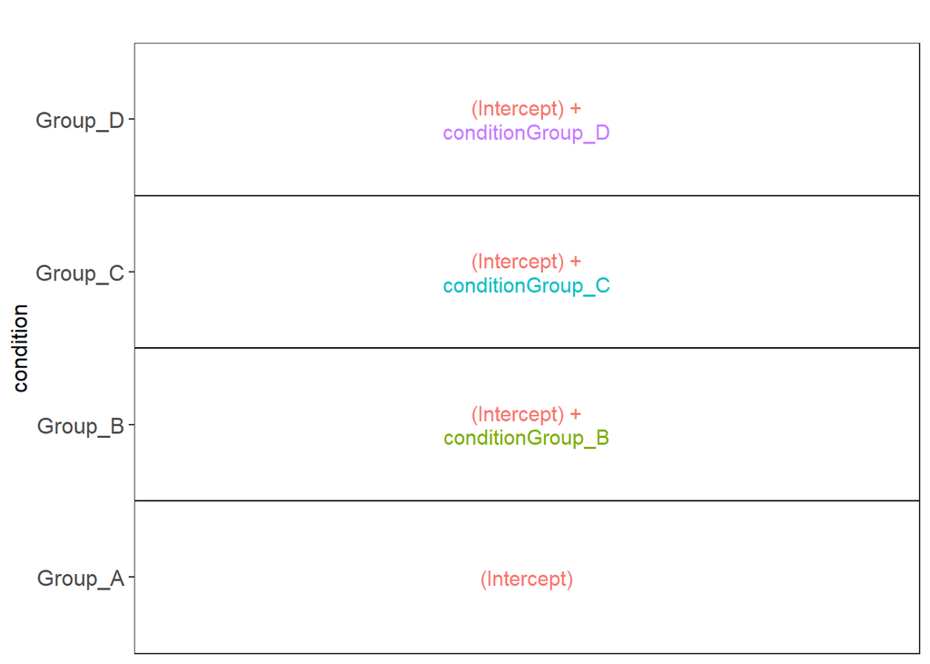

```r
vd =
  ExploreModelMatrix::VisualizeDesign(
    sampleData =  colData(pep),
    designFormula = ~condition,
    textSizeFitted = 4
    )

vd$plotlist
```

Based on this null hypothesis we now generate a contrast matrix to then test the null hypothesis using `hypothesisTest()` which takes the QFeatures object with the fitted model and the contrast we just built. msqrob2 automatically applies the hypothesis testing to all features in the assay.

```r
# check condition name
msqrob2::getCoef(rowData(pep[["prot"]])$msqrobModels[[1]])
```

```
     (Intercept) conditionGroup_B conditionGroup_C conditionGroup_D
      -0.4801935       -2.3422855       -0.4594311       -0.7825567
```

```r
# make contrast
contrast =
  msqrob2::makeContrast(
    contrasts = c(
      "conditionGroup_B = 0",
      "conditionGroup_C = 0",
      "conditionGroup_D - conditionGroup_C = 0",
      "conditionGroup_D - conditionGroup_B = 0"
      ),
    parameterNames =
      colnames(vd$designmatrix)
    )

# hypothesis test
pep = msqrob2::hypothesisTest(object = pep, i = "prot", contrast = contrast)
```

The results of the statistical testing can be inspected via the `msqrobCollect()` function from the msqrob2 package - this function automatically retrieves the results for all contrasts in one table that contains two additional columns: contrast with the name of the contrast and feature with the name of the modelled feature, here protein. These results are shown in Table 3.

```r
# Extract comparison data
compData = msqrob2::msqrobCollect(pep[["prot"]], contrast = contrast)

# Reorganize compData
compData =
  compData |>
  dplyr::filter(!is.na(adjPval)) |>
  dplyr::rename(Protein = "feature") |>
  dplyr::left_join(protein_data, by = "Protein") |>
  dplyr::relocate(Protein, Gene, contrast)

#write.xlsx(x = compData, file = "Comparison_results.xlsx")

compData |>
  DT::datatable(
    rownames = FALSE,
              extensions = 'Buttons',
              options = list(dom = 'Bfrtip', buttons = 'excel'))
```

| Protein | Gene | contrast | logFC | se | df | t | pval | adjPval | Group_A_1 | Group_A_2 | Group_A_3 | Group_B_1 | Group_B_2 | Group_B_3 | Group_C_1 | Group_C_2 | Group_C_3 | Group_D_1 | Group_D_2 | Group_D_3 |
| --- | --- | --- | --- | --- | --- | --- | --- | --- | --- | --- | --- | --- | --- | --- | --- | --- | --- | --- | --- | --- |
| A0A075B5P3 | Ighg2b | conditionGroup_B | -2.342285541962402 | 0.6136885829934727 | 11.58041282300838 | -3.816733123072155 | 0.002611341125352005 | 0.0560814479826479 | -0.4861776733465524 | -1.615555307519695 | 0.6719524480657543 | -3.299194498166964 | -2.345763568913743 |  | -0.670260312931902 | -1.905223998532602 | -0.254669098223029 | -1.006848361829505 | -1.267506201651704 | -1.513895936565053 |
| A0A075B5P4 | Ighg1 | conditionGroup_B | -2.291771178474325 | 0.4431273574785435 | 12.56671798355507 | -5.171811534080909 | 0.000200381080586541 | 0.008824189067311007 | -0.1022458998650002 | 0.4500501091043301 | 0.6174538716975951 | -1.404664424612841 | -3.280284622967718 | -1.700857008232351 | 0.7221243118470024 | 0.7369076826139017 | 1.197059532495791 | 1.083146917554394 | -0.1618521081745907 | 0.3211032478213021 |
| A0A087WPF8 | Abhd14b | conditionGroup_B | 0.06511843255825434 | 0.336952387159256 | 11.61599249583608 | 0.1932570744111601 | 0.8500955080839891 | 0.9481834513244495 | -1.025529309232978 | 0.37889802036436 | -0.373164606418634 | 0.002102646201636079 | -0.3675743872372551 | -0.5123556564642932 | -0.2448256923127692 | -0.4480011751434081 | -0.8638637585951621 | -0.6434275160316681 | -0.7285244410267842 | -0.6052344865021638 |
| A0A087WPJ7 | Dnajc13 | conditionGroup_B | 1.232353271169453 | 0.323960320860263 | 9.929812615613992 | 3.804025344514387 | 0.003507011028844541 | 0.06892291096357289 |  | -2.836157442331638 | -3.62578153686834 | -2.197193988597109 | -1.939439990036962 | -1.859214676657536 |  | -3.407139982166049 |  | -1.427439218503348 | -1.907680925404318 | -1.626333491892396 |
| A0A087WPL5 | Dhx9 | conditionGroup_B | 0.4065109076488189 | 0.2859571123942681 | 11.21366311286555 | 1.421579985352262 | 0.1823587191152665 | 0.4973039381377336 | -1.334846859242937 | -0.5363534279114798 | -0.7520465725713635 | -0.4787076506621706 | -0.3905592231483503 | -0.3609552762723942 | -0.3462723135507812 | -0.6383788442573042 | -1.095413742209924 | -0.4598138432125835 | -0.588698372876309 | -0.3705059669041968 |
| A0A087WRY1 | Fn1 | conditionGroup_B | -2.279487907290941 | 0.368994811105527 | 12.52569437358152 | -6.177560872635257 | 3.930491832443301e-05 | 0.00318863985731934 | 0.4882506501016364 | 1.567449830951872 | 1.418921639093239 | -1.375857803951626 | -1.275547711441897 | -0.5899211691941832 | 2.01402012450101 | 2.225614523785394 | 1.037192289258638 | 1.808757056371106 | 1.469084718727595 | 1.827668511124921 |
| A0A087WS16 | Col6a3 | conditionGroup_B | -0.5461412192887598 | 0.290547176612119 | 10.21395786599862 | -1.879698937903841 | 0.08894895163320997 | 0.370747370533244 | 3.163339253380062 | 3.812978415847274 | 3.600423792797005 | 3.069473570644023 | 2.994101475598957 | 3.004737005579898 | 3.491713990483223 | 3.813324823867081 | 2.971047695803865 | 3.112095865095319 | 3.130762891495059 | 3.197233899389591 |
| A0A0A6YX73 | Prkar2a | conditionGroup_B | 0.7409479465263796 | 0.293233813084748 | 12.04087608194695 | 2.526816190574301 | 0.02651671894610072 | 0.2087972107742632 | -1.267633786360161 | -0.9959527175635117 | -0.891842451052483 | -0.396365163917649 | -0.3820805717500325 | -0.1541393797293341 | -0.2643111693057935 | -1.504164778724135 | -0.5904607527853113 | -0.1513465126354322 | -0.8042554954257768 | -0.3216057263157015 |
| A0A0A6YY47 | Ncam1 | conditionGroup_B | -0.4524086855651914 | 0.2768082804635283 | 12.92419681799326 | -1.634375549776228 | 0.1262900577064287 | 0.4284133483964159 | 0.2740706402814947 | 1.001163884319478 | 0.9440165495901515 | 0.616599892391046 | 0.268385937512805 | -0.02034074476728421 | 1.030117969424881 | 0.7255384640896123 | 0.4875649564645174 | 0.8801765268838599 | 0.5905613442380111 | 0.8224170336868908 |
| A0A0J9YUD5 | Nup205 | conditionGroup_B | 0.2873041764539166 | 0.3836313945779715 | 9.747933980643369 | 0.7489068426476844 | 0.4715977865588964 | 0.74584088237443 |  | -2.404916452794107 | -2.365018133795042 | -1.976690970941644 | -2.609486905677738 | -1.70681147390259 |  | -2.920381991218693 |  | -1.619813033887384 | -2.627533024398476 | -1.733562978570082 |

[output cut: 9447 more lines]

## Volcano plots

A volcano plot is a common visualisation that provides an overview of the hypothesis testing results, plotting the −log(10)-P-value as a function of the estimated log(2)-fold change. Volcano plots can be used to highlight the most interesting proteins that have large fold changes and/or are highly significant.

To generate the volcano plot, by default we set some thresholds:

- adjusted P-value < 0.05 (5%)
- log2FC > 0.5 (corresponds to a 1.41-fold increase, or a 41% increase) or < -0.5 (correspond to a decrease greater than approximately 29.3%).

The proteins that pass these thresholds are highlighted in Figure 8 (Group B vs. Group A), Figure 9 (Group D vs. Group C), Figure 10 (Group D vs. Group B), and Figure 11 (Group C vs. Group A)

```r
compData$label <- "Not-significant"
compData$label[compData$adjPval < 0.05 & compData$logFC > 0.5] <- "Up-regulated"
compData$label[compData$adjPval < 0.05 & compData$logFC < -0.5] <- "Down-regulated"

volcano_BA =
  compData |>
  dplyr::filter(contrast == "conditionGroup_B") |>
  ggplot(aes(x = logFC, y = -log(pval))) +
  geom_point(aes(color = label), size = 1) +
  labs(color = "") +
  scale_color_manual(values = c("blue", "gray", "red")) +
  geom_text_repel(aes(label =
                        ifelse(label == "Down-regulated"|label == "Up-regulated",
                               Gene, ""), max.overlaps = 30)) +
  theme_light() +
  theme(axis.text = element_text(size = 10, color = "black"),
        panel.border = element_rect(color = "black"),
        panel.grid = element_blank(),
        legend.text = element_text(size = 10)
        )

volcano_DC =
  compData |>
  dplyr::filter(contrast == "conditionGroup_D - conditionGroup_C") |>
  ggplot(aes(x = logFC, y = -log(pval))) +
  geom_point(aes(color = label), size = 1) +
  labs(color = "") +
  scale_color_manual(values = c("blue", "gray", "red")) +
  geom_text_repel(aes(label =
                        ifelse(label == "Down-regulated"|label == "Up-regulated",
                               Gene, ""), max.overlaps = 30)) +
  theme_light() +
  theme(axis.text = element_text(size = 10, color = "black"),
        panel.border = element_rect(color = "black"),
        panel.grid = element_blank(),
        legend.text = element_text(size = 10)
        )

volcano_DB =
  compData |>
  dplyr::filter(contrast == "conditionGroup_D - conditionGroup_B") |>
  ggplot(aes(x = logFC, y = -log(pval))) +
  geom_point(aes(color = label), size = 1) +
  labs(color = "") +
  scale_color_manual(values = c("blue", "gray", "red")) +
  geom_text_repel(aes(label =
                        ifelse(label == "Down-regulated"|label == "Up-regulated",
                               Gene, ""), max.overlaps = 30)) +
  theme_light() +
  theme(axis.text = element_text(size = 10, color = "black"),
        panel.border = element_rect(color = "black"),
        panel.grid = element_blank(),
        legend.text = element_text(size = 10)
        )

volcano_C =
  compData |>
  dplyr::filter(contrast == "conditionGroup_C") |>
  ggplot(aes(x = logFC, y = -log(pval))) +
  geom_point(aes(color = label), size = 1) +
  labs(color = "") +
  scale_color_manual(values = c("blue", "gray", "red")) +
  geom_text_repel(aes(label =
                        ifelse(label == "Down-regulated"|label == "Up-regulated",
                               Gene, ""), max.overlaps = 30)) +
  theme_light() +
  theme(axis.text = element_text(size = 10, color = "black"),
        panel.border = element_rect(color = "black"),
        panel.grid = element_blank(),
        legend.text = element_text(size = 10)
        )
```

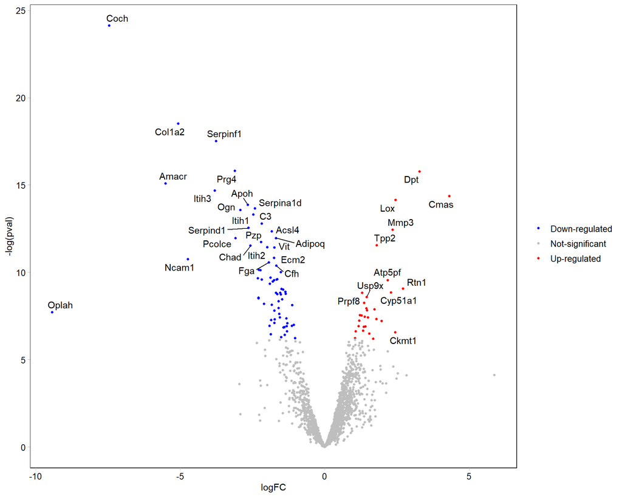

Figure 8: Volcano plot showing proteins differentially abundant from the multiple testing comparisons: Group B (oim/oim) vs. Group A (WT)

```r
volcano_BA
```

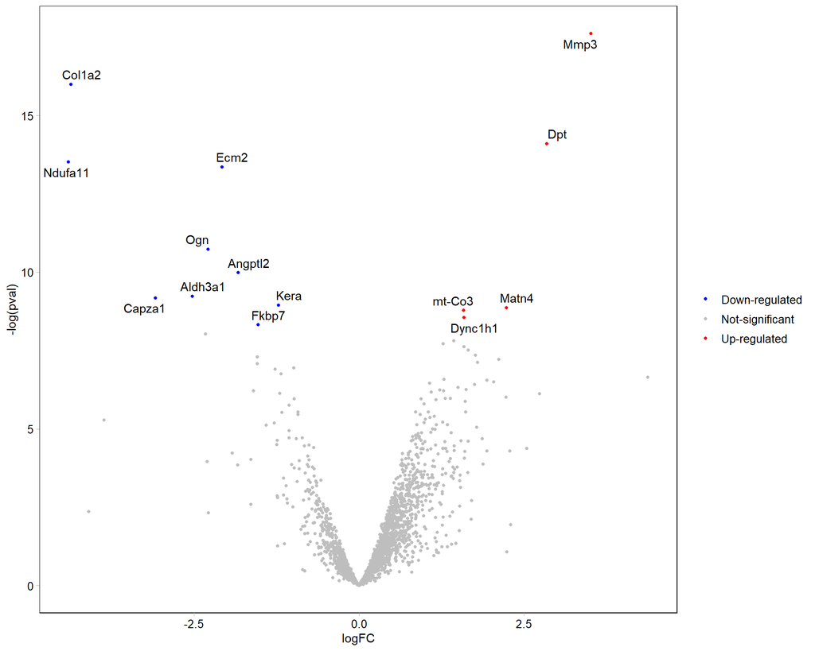

Figure 9: Volcano plot showing proteins differentially abundant from the multiple testing comparisons: Group D (Col1a2 -/-) vs. Group C (WT)

```r
volcano_DC
```

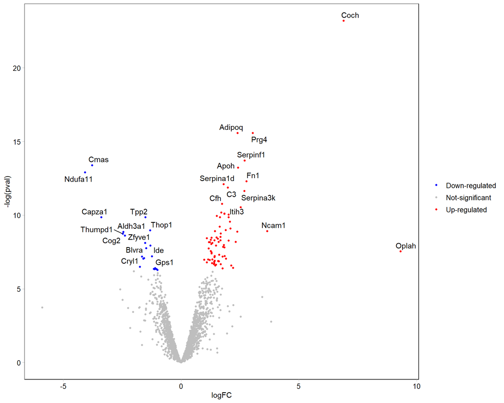

Figure 10: Volcano plot showing proteins differentially abundant from the multiple testing comparisons: Group D (Col1a2 -/-) vs. Group B (oim/oim homozygous).

```r
volcano_DB
```

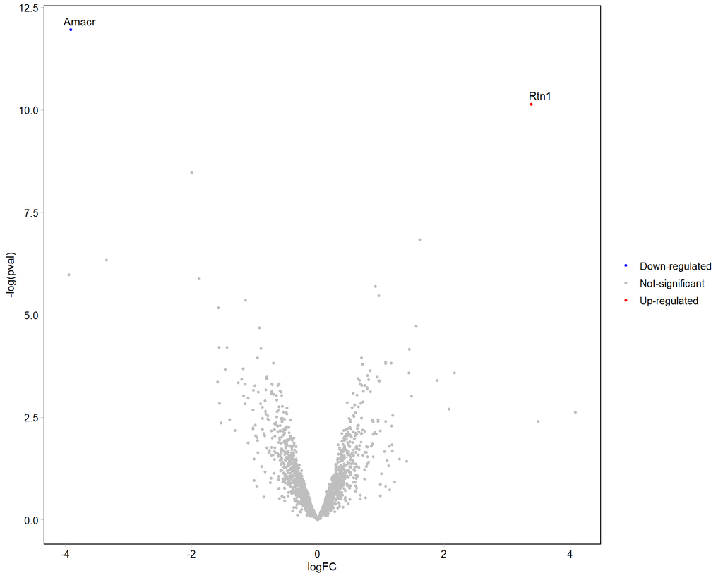

Figure 11: Volcano plot showing proteins differentially abundant from the multiple testing comparisons: Group C (WT for Col1a2 -/-) vs. Group A (WT for oim/oim homozygous)

```r
volcano_C
```

```r
#ggsave("volcano_BA.png", plot = volcano_BA, dpi = 600, width = 10, height = 8)
#ggsave("volcano_DC.png", plot = volcano_DC, dpi = 600, width = 10, height = 8)
#ggsave("volcano_DB.png", plot = volcano_DB, dpi = 600, width = 10, height = 8)
#ggsave("volcano_CA.png", plot = volcano_C,  dpi = 600, width = 10, height = 8)
```

## Heat map of proteins differentially abundant

We construct heat maps for the significant proteins for each comparison using the **pheatmap** package. We get the names of the significant features, extract the quantitative data for the significant features and scale it (via z-score transformation), and, optionally, perform hierarchical clustering (by default) on both rows and columns using Euclidean distance and complete linkage.

Figure 12 shows the heatmap for the proteins selected from the comparison between Group B and Group A.

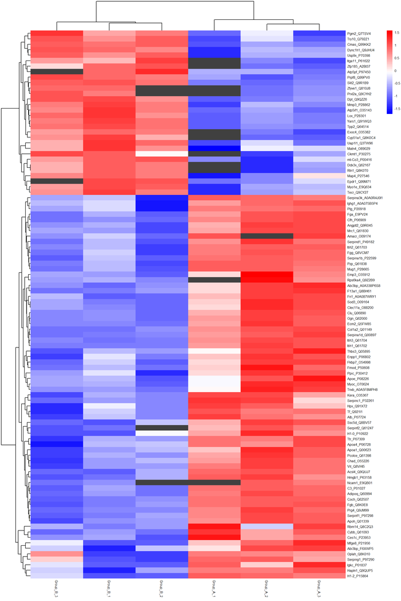

Figure 12: Heat map showing proteins differentially abundant from the multiple testing comparisons: Group B (oim/oim) vs. Group A (WT)

```r
png(filename = "heatmap_BA.png", width = 12, height = 22, units = "cm", res = 600)
compData |>
  dplyr::mutate(ID = paste0(Gene, "_", Protein)) |>
  dplyr::filter(contrast == "conditionGroup_B") |>
  dplyr::arrange(logFC) |>
  dplyr::filter(adjPval < 0.05) |>
  dplyr::filter(logFC > 0.5 | logFC < -0.5) |>
  dplyr::select(10:15, ID) |>
  column_to_rownames(var = "ID") |>
  apply(1, zscore_custom) |>
  t() |>
  pheatmap(
    color = colorRampPalette(c("blue", "white", "red"))(50),
    na_col = "gray25",
    cluster_rows = T,
    cluster_cols = T,
    show_colnames = T,
    border_color = NA,
    fontsize = 6
    )
dev.off()
```

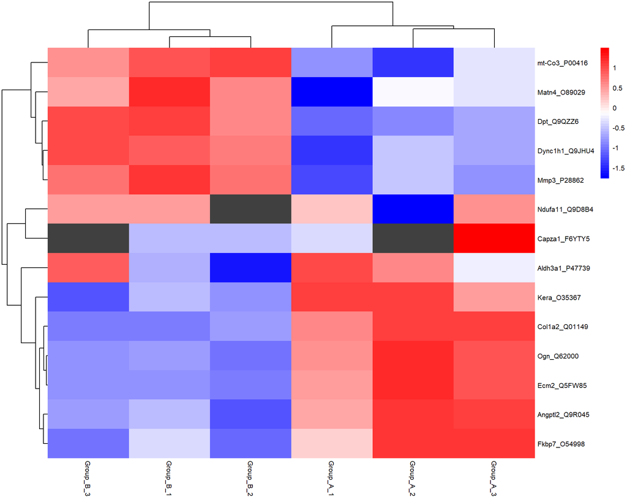

```r
#png(filename = "heatmap_DC.png", width = 12, height = 8, units = "cm", res = 600)
compData |>
  dplyr::mutate(ID = paste0(Gene, "_", Protein)) |>
  dplyr::filter(contrast == "conditionGroup_D - conditionGroup_C") |>
  dplyr::arrange(logFC) |>
  dplyr::filter(adjPval < 0.05) |>
  dplyr::filter(logFC > 0.5 | logFC < -0.5) |>
  dplyr::select(10:15, ID) |>
  column_to_rownames(var = "ID") |>
  apply(1, zscore_custom) |>
  t() |>
  pheatmap(
    color = colorRampPalette(c("blue", "white", "red"))(50),
    na_col = "gray25",
    cluster_rows = T,
    cluster_cols = T,
    show_colnames = T,
    border_color = NA,
    fontsize = 8
    )
#dev.off()
```

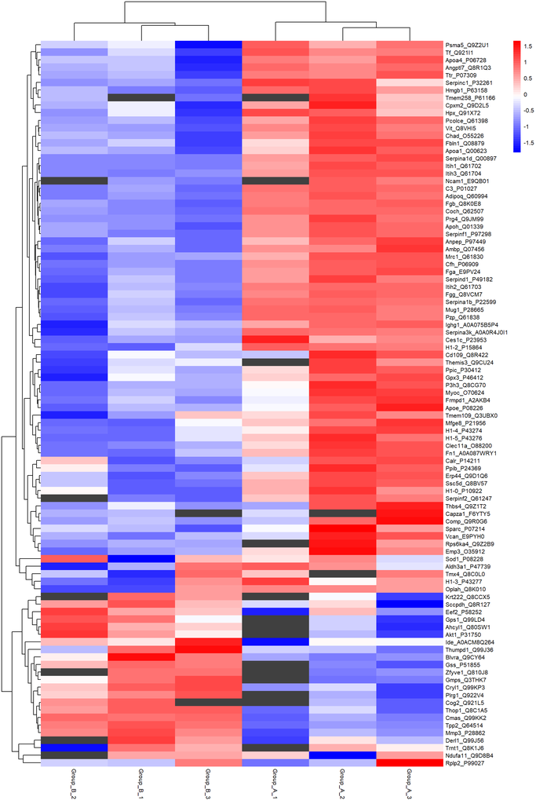

```r
#png(filename = "heatmap_DB.png", width = 12, height = 15, units = "cm", res = 600)
compData |>
  dplyr::mutate(ID = paste0(Gene, "_", Protein)) |>
  dplyr::filter(contrast == "conditionGroup_D - conditionGroup_B") |>
  dplyr::arrange(logFC) |>
  dplyr::filter(adjPval < 0.05) |>
  dplyr::filter(logFC > 0.5 | logFC < -0.5) |>
  dplyr::select(10:15, ID) |>
  column_to_rownames(var = "ID") |>
  apply(1, zscore_custom) |>
  t() |>
  pheatmap(
    color = colorRampPalette(c("blue", "white", "red"))(50),
    na_col = "gray25",
    cluster_rows = T,
    cluster_cols = T,
    show_colnames = T,
    border_color = NA,
    fontsize = 8
    )
#dev.off()
```

# Gene ontology and pathway enrichment analysis

Gene Ontology (GO) and pathway enrichment analyses are used in proteomics to identify biological processes, molecular functions, cellular components, and signalling or metabolic pathways that are overrepresented among proteins of interest. By comparing a selected protein list, such as differentially abundant proteins, with an appropriate background set of detected proteins, these analyses help translate protein-level changes into broader biological themes. They are therefore useful for generating hypotheses, identifying coordinated cellular responses, and interpreting the functional significance of proteomic datasets.

For this, we use the **culsterProfiler** package, which automates functional enrichment analysis and implements methods to analyze and visualize functional GO profiles of proteins and protein clusters. To perform the GO analysis, we select as background the set of proteins detected and eligible for statistical testing in the study (not the whole species-specific proteome, which will contain proteins that were never measurable in this experiment) because GO enrichment asks whether a category occurs more often than expected among your selected proteins, and the expectation must reflect the proteins that could realistically have entered that selected list.

## GO enrichment analysis

For this study, we selected the **2356 proteins** detected across the samples in the study. Next, we extract the proteins that were identified as up- and down-regulated based on the thresholds established before (i.e., adjusted p-value < 0.05, log(2)-fold change > 0.5 or < -0.5) and test them against the protein background.

```r
# Define protein background (universe)
library(org.Mm.eg.db)

# Proteins to be tested
padj_cutoff = 0.05
lfc_cutoff  = 0.5

compData_clean =
  compData |>
  dplyr::transmute(
    contrast = as.character(contrast),
    Protein     = as.character(Protein),
    logFC    = as.numeric(logFC),
    adjPval  = as.numeric(adjPval)
  ) |>
  dplyr::filter(
    !is.na(Protein),
    Protein != ""
    )

universe_symbols =
  compData_clean |>
  dplyr::filter(!is.na(adjPval)) |>
  dplyr::pull(Protein) |>
  unique()
```

Figure 15 shows the top 20 GO terms enriched for the proteins significantly regulated from the comparison between Group B vs. Group A.

```r
# Define significant up- and down-regulated proteins: Group B vs. Group A
up =
  compData_clean |>
  dplyr::filter(
    contrast == "conditionGroup_B",
    !is.na(adjPval),
    adjPval < padj_cutoff,
    logFC > lfc_cutoff
    ) |>
  dplyr::pull(Protein) |>
  unique()

down =
  compData_clean |>
  dplyr::filter(
    contrast == "conditionGroup_B",
    !is.na(adjPval),
    adjPval < padj_cutoff,
    logFC < lfc_cutoff
    ) |>
  dplyr::pull(Protein) |>
  unique()

combined =
  c(up, down) |>
  unlist() |>
  unique()

gene_lists =
  list(
    Upregulated   = up,
    Downregulated = down,
    Combined      = combined
    )

# GO enrichment analysis
stopifnot(
  all(up %in% universe_symbols),
  all(down %in% universe_symbols)
  )

run_go = function(ontology) {
  clusterProfiler::compareCluster(
    geneCluster   = gene_lists,
    fun           = "enrichGO",
    universe      = universe_symbols,
    OrgDb         = org.Mm.eg.db,
    keyType       = "UNIPROT",
    ont           = ontology,
    pAdjustMethod = "fdr",
    pvalueCutoff  = 0.05,
    qvalueCutoff  = 0.10,
    minGSSize     = 2,
    maxGSSize     = 500,
    readable      = TRUE
  )
  }

go_results =
  run_go("all") |>
  clusterProfiler::simplify()

# filter explicitly by adjusted p-value
go_table_BA =
  as.data.frame(go_results) |>
  dplyr::filter(p.adjust < 0.10) |>
  dplyr::arrange(p.adjust) |>
  dplyr::mutate(comparison = "Group B vs. Group A")
```

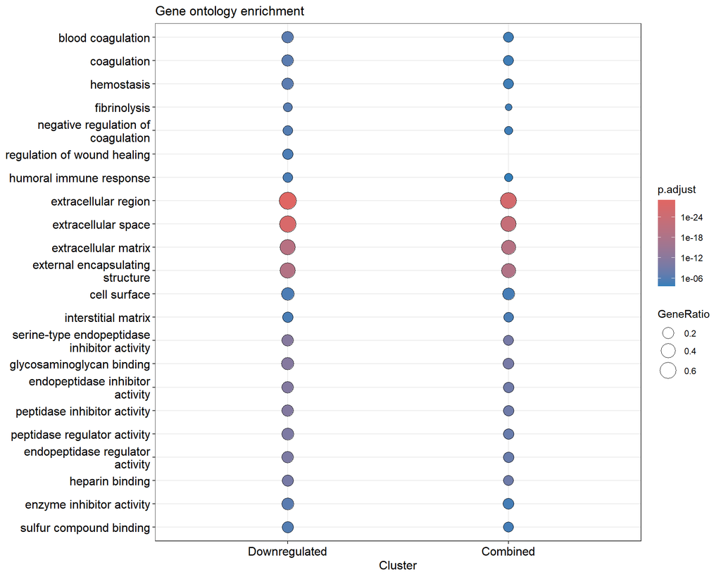

Figure 15: GO terms enriched for proteins differentially abundant: Group B (oim/oim) vs. Group A (WT)

```r
plot_GO_BA =
  enrichplot::dotplot(
    go_results,
    showCategory = 20
    ) +
  ggplot2::ggtitle("Gene ontology enrichment")

plot_GO_BA
```

Figure 16 shows the GO terms enriched for the proteins significantly regulated from the comparison between Group D vs. Group C.

```r
# Define significant up- and down-regulated proteins: Group D vs. Group C
up =
  compData_clean |>
  dplyr::filter(
    contrast == "conditionGroup_D - conditionGroup_C",
    !is.na(adjPval),
    adjPval < padj_cutoff,
    logFC > lfc_cutoff
    ) |>
  dplyr::pull(Protein) |>
  unique()

down =
  compData_clean |>
  dplyr::filter(
    contrast == "conditionGroup_D - conditionGroup_C",
    !is.na(adjPval),
    adjPval < padj_cutoff,
    logFC < lfc_cutoff
    ) |>
  dplyr::pull(Protein) |>
  unique()

combined =
  c(up, down) |>
  unlist() |>
  unique()

gene_lists =
  list(
    Upregulated   = up,
    Downregulated = down,
    Combined      = combined
    )

# GO enrichment analysis
stopifnot(
  all(up %in% universe_symbols),
  all(down %in% universe_symbols)
  )

run_go = function(ontology) {
  clusterProfiler::compareCluster(
    geneCluster   = gene_lists,
    fun           = "enrichGO",
    universe      = universe_symbols,
    OrgDb         = org.Mm.eg.db,
    keyType       = "UNIPROT",
    ont           = ontology,
    pAdjustMethod = "fdr",
    pvalueCutoff  = 0.05,
    qvalueCutoff  = 0.10,
    minGSSize     = 2,
    maxGSSize     = 500,
    readable      = TRUE
  )
  }

go_results =
  run_go("all") |>
  clusterProfiler::simplify()

# filter explicitly by adjusted p-value
go_table_DC =
  as.data.frame(go_results) |>
  dplyr::filter(p.adjust < 0.10) |>
  dplyr::arrange(p.adjust) |>
  dplyr::mutate(comparison = "Group D vs. Group C")
```

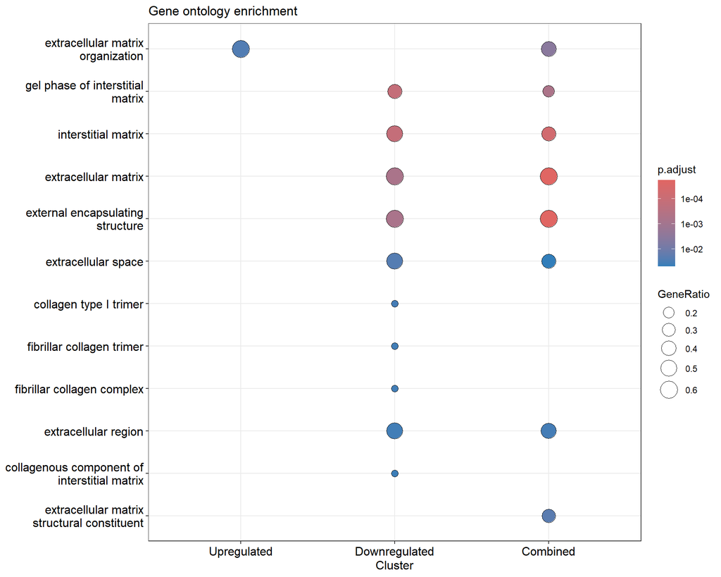

Figure 16: GO terms enriched for proteins differentially abundant: Group D (Col1a2 -/-) vs. Group C (WT)

```r
plot_GO_DC =
  enrichplot::dotplot(
    go_results,
    showCategory = 20
    ) +
  ggplot2::ggtitle("Gene ontology enrichment")

plot_GO_DC
```

Figure 17 shows the GO terms enriched for the proteins significantly regulated from the comparison between Group D vs. Group B.

```r
# Define significant up- and down-regulated proteins: Group D vs. Group B
up =
  compData_clean |>
  dplyr::filter(
    contrast == "conditionGroup_D - conditionGroup_B",
    !is.na(adjPval),
    adjPval < padj_cutoff,
    logFC > lfc_cutoff
    ) |>
  dplyr::pull(Protein) |>
  unique()

down =
  compData_clean |>
  dplyr::filter(
    contrast == "conditionGroup_D - conditionGroup_B",
    !is.na(adjPval),
    adjPval < padj_cutoff,
    logFC < lfc_cutoff
    ) |>
  dplyr::pull(Protein) |>
  unique()

combined =
  c(up, down) |>
  unlist() |>
  unique()

gene_lists =
  list(
    Upregulated   = up,
    Downregulated = down,
    Combined      = combined
    )

# GO enrichment analysis
stopifnot(
  all(up %in% universe_symbols),
  all(down %in% universe_symbols)
  )

run_go = function(ontology) {
  clusterProfiler::compareCluster(
    geneCluster   = gene_lists,
    fun           = "enrichGO",
    universe      = universe_symbols,
    OrgDb         = org.Mm.eg.db,
    keyType       = "UNIPROT",
    ont           = ontology,
    pAdjustMethod = "fdr",
    pvalueCutoff  = 0.05,
    qvalueCutoff  = 0.10,
    minGSSize     = 2,
    maxGSSize     = 500,
    readable      = TRUE
  )
  }

go_results =
  run_go("all") |>
  clusterProfiler::simplify()

# filter explicitly by adjusted p-value
go_table_DB =
  as.data.frame(go_results) |>
  dplyr::filter(p.adjust < 0.10) |>
  dplyr::arrange(p.adjust) |>
  dplyr::mutate(comparison = "Group D vs. Group B")
```

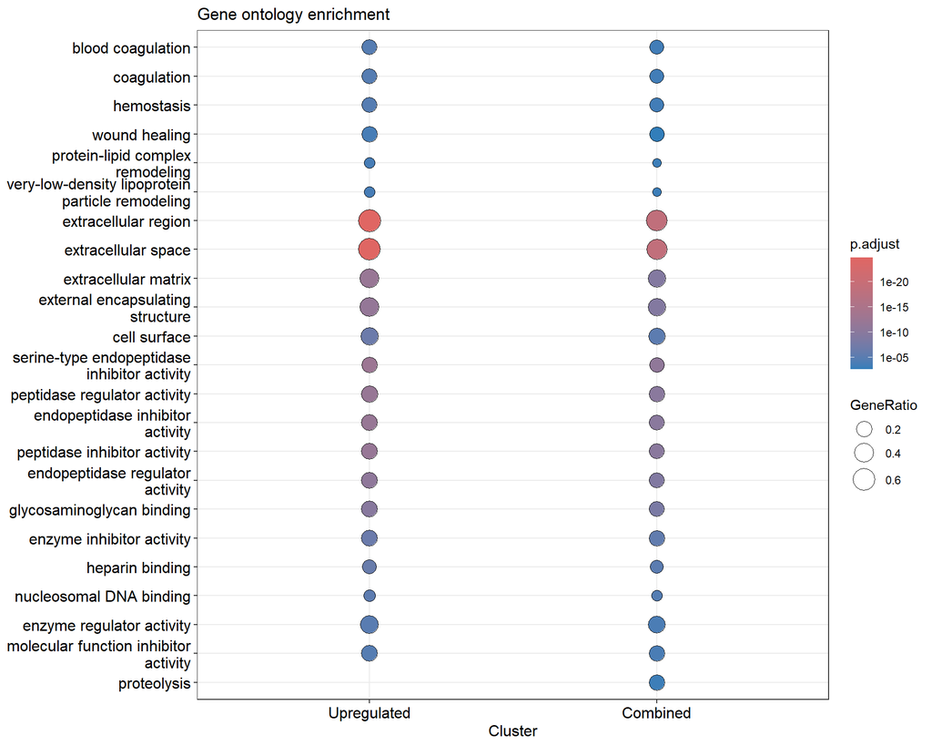

Figure 17: GO terms enriched for proteins differentially abundant: Group D (Col1a2 -/-) vs. Group B (oim/oim)

```r
plot_GO_DB =
  enrichplot::dotplot(
    go_results,
    showCategory = 20
    ) +
  ggplot2::ggtitle("Gene ontology enrichment")

plot_GO_DB
```

```r
go_table =
  dplyr::bind_rows(
    go_table_BA,
    go_table_DC,
    go_table_DB
  )

#write.xlsx(x = go_table, file = "GO_results.xlsx")
```

```r
#ggsave("plot_GO_BA.png", plot = plot_GO_BA, dpi = 600, width = 10, height = 8)
#ggsave("plot_GO_DC.png", plot = plot_GO_DC, dpi = 600, width = 10, height = 8)
#ggsave("plot_GO_DB.png", plot = plot_GO_DB, dpi = 600, width = 10, height = 8)
```